# R Notebook

```r
library(tidyverse)
library(janitor)
library(ggplot2)

green_blue_comp_data <- read_csv("data/complete_dist_blue_green.csv") %>% clean_names()
neighbourhood_comp_data <- read_csv("data/complete_neighbourhood_rating.csv") %>% clean_names()
community_comp_data <- read_csv("data/complete_community_belonging.csv") %>% clean_names()
```

I really want to work out if we can get all these bound together in one big dataset.

```r
green_blue_comp_data %>%
  glimpse()
```

```
Rows: 38,451
Columns: 13
$ feature_code                            <chr> "S12000030", "S12000050", "S92000003", "S12000034", "…
$ date_code                               <dbl> 2013, 2019, 2015, 2013, 2017, 2014, 2018, 2016, 2014,…
$ measurement                             <chr> "Percent", "Percent", "95% Upper Confidence Limit, Pe…
$ units                                   <chr> "Percent Of Adults", "Percent Of Adults", "Percent Of…
$ value                                   <dbl> 20.0, 21.0, 19.0, 2.0, 14.0, 2.8, 10.8, 8.7, 79.4, 61…
$ distance_to_nearest_green_or_blue_space <chr> "Within a 6-10 minute walk", "An 11 minute walk or mo…
$ age                                     <chr> "All", "All", "All", "All", "All", "All", "All", "All…
$ gender                                  <chr> "All", "All", "All", "All", "All", "All", "All", "All…
$ urban_rural_classification              <chr> "All", "All", "All", "All", "All", "All", "All", "All…
$ simd_quintiles                          <chr> "All", "All", "All", "All", "All", "All", "All", "All…
$ type_of_tenure                          <chr> "All", "All", "All", "All", "All", "All", "All", "All…
$ household_type                          <chr> "With Children", "With Children", "With Children", "W…
$ ethnicity                               <chr> "All", "All", "All", "All", "All", "All", "All", "All…
```

```r
neighbourhood_comp_data %>%
  glimpse()
```

```
Rows: 38,055
Columns: 13
$ feature_code                           <chr> "S12000008", "S12000026", "S12000020", "S12000010", "S…
$ date_code                              <dbl> 2014, 2014, 2014, 2017, 2017, 2019, 2017, 2017, 2014, …
$ measurement                            <chr> "95% Upper Confidence Limit, Percent", "95% Upper Conf…
$ units                                  <chr> "Percent Of Adults", "Percent Of Adults", "Percent Of …
$ value                                  <dbl> 60.7, 51.8, 0.0, 64.0, 55.4, 89.9, 71.6, 89.0, 1.0, 73…
$ neighbourhood_rating                   <chr> "Very good", "Fairly good", "No opinion", "Very good",…
$ gender                                 <chr> "All", "All", "All", "All", "All", "All", "All", "All"…
$ urban_rural_classification             <chr> "Urban", "Urban", "Urban", "Urban", "Urban", "Urban", …
$ simd_quintiles                         <chr> "All", "All", "All", "All", "All", "All", "All", "All"…
$ type_of_tenure                         <chr> "All", "All", "All", "All", "All", "All", "All", "All"…
$ household_type                         <chr> "All", "All", "All", "All", "All", "All", "All", "All"…
$ ethnicity                              <chr> "All", "All", "All", "All", "All", "All", "All", "All"…
$ walking_distance_to_nearest_greenspace <chr> "All", "All", "All", "All", "All", "All", "All", "All"…
```

```r
community_comp_data %>%
  glimpse()
```

```
Rows: 43,611
Columns: 13
$ feature_code                           <chr> "S12000030", "S12000033", "S12000029", "S12000029", "S…
$ date_code                              <dbl> 2014, 2014, 2014, 2018, 2015, 2014, 2019, 2015, 2019, …
$ measurement                            <chr> "Percent", "95% Upper Confidence Limit, Percent", "95%…
$ units                                  <chr> "Percent Of Adults", "Percent Of Adults", "Percent Of …
$ value                                  <dbl> 44.0, 35.7, 39.3, 2.0, 0.0, 50.2, 8.0, 33.3, 7.0, 7.0,…
$ community_belonging                    <chr> "Very strongly", "Very strongly", "Very strongly", "Do…
$ gender                                 <chr> "All", "All", "All", "All", "All", "All", "Male", "Mal…
$ urban_rural_classification             <chr> "All", "All", "All", "All", "All", "All", "All", "All"…
$ simd_quintiles                         <chr> "All", "All", "All", "80% least deprived", "All", "All…
$ type_of_tenure                         <chr> "All", "All", "All", "All", "All", "All", "All", "All"…
$ household_type                         <chr> "All", "All", "All", "All", "All", "All", "All", "All"…
$ ethnicity                              <chr> "All", "All", "All", "All", "All", "All", "All", "All"…
$ walking_distance_to_nearest_greenspace <chr> "All", "All", "All", "All", "All", "All", "All", "All"…
```

```r
codes_gb <-
green_blue_comp_data %>%
  distinct(feature_code)

codes_gb
```

| feature_code |
| --- |
| S12000030 |
| S12000050 |
| S92000003 |
| S12000034 |
| S12000033 |
| S12000035 |
| S12000011 |
| S12000021 |
| S12000039 |
| S12000028 |

[output cut: 23 more lines]

```r
green_blue_comp_data %>%
  distinct(units)
```

| units |
| --- |
| Percent Of Adults |

```r
codes_neigh <-
neighbourhood_comp_data %>%
  distinct(feature_code)

codes_neigh
```

| feature_code |
| --- |
| S12000008 |
| S12000026 |
| S12000020 |
| S12000010 |
| S12000039 |
| S12000023 |
| S12000013 |
| S12000033 |
| S12000011 |
| S12000029 |

[output cut: 23 more lines]

```r
neighbourhood_comp_data %>%
  distinct(units)
```

| units |
| --- |
| Percent Of Adults |

```r
codes_community <-
community_comp_data %>%
  distinct(feature_code)

community_comp_data %>%
  distinct(units)
```

| units |
| --- |
| Percent Of Adults |

Cool, so all three datasets seem to have the same amount of variables, altough there will be a slight difference in the measure of each. The thing I want to get checking is that feature codes refer to regions or, more likely, council areas. I also just want to double check that these are all the same in each dataset. I’m pretty sure we actually have the codes down for this in the previous report which would be super handy.

```r
all_equal(codes_community, codes_gb, codes_neigh)
```

```
[1] TRUE
```

Sweet, it looks like all the codes match which I’m hoping means we can just do a join on all these. Not sure whether to change the codes now or after. Think I might just do now so the join is a bit clearer for me, although I’m guessing it would be best practice to do it after.

My mistake earlier, just realised those were NHS codes not council ones.

```r
local_authority_codes <- read_csv("data/Local_Authority_Districts_Codes.csv") %>% clean_names()
```

```r
local_authority_codes %>%
  distinct(lad19cd)
```

| lad19cd |
| --- |
| E06000001 |
| E07000215 |
| E07000084 |
| E06000002 |
| E06000003 |
| E06000004 |
| E07000216 |
| E07000217 |
| E06000005 |
| E06000006 |

[output cut: 372 more lines]

```r
scot_local_auth_codes <-
local_authority_codes %>%
  filter(str_detect(lad19cd, "S12")) %>%
  select(lad19cd, lad19nm) %>%
  rename(feature_code = lad19cd,
         local_authority = lad19nm)
```

```r
#Adding a local authority column to each of the datasets
gb_with_las_data <-
full_join(green_blue_comp_data, scot_local_auth_codes, "feature_code")

gb_with_las_data <-
gb_with_las_data %>%
  mutate(local_authority = if_else(feature_code == "S92000003", "Scotland", local_authority))

gb_with_las_data
```

| feature_code | date_code | measurement | units | value | distance_to_nearest_green_or_blue_space | age | gender | urban_rural_classification | simd_quintiles | type_of_tenure | household_type | ethnicity | local_authority |
| --- | --- | --- | --- | --- | --- | --- | --- | --- | --- | --- | --- | --- | --- |
| S12000030 | 2013 | Percent | Percent Of Adults | 20.0 | Within a 6-10 minute walk | All | All | All | All | All | With Children | All | Stirling |
| S12000050 | 2019 | Percent | Percent Of Adults | 21.0 | An 11 minute walk or more | All | All | All | All | All | With Children | All | North Lanarkshire |
| S92000003 | 2015 | 95% Upper Confidence Limit, Percent | Percent Of Adults | 19.0 | Within a 6-10 minute walk | All | All | All | All | All | With Children | All | Scotland |
| S12000034 | 2013 | 95% Lower Confidence Limit, Percent | Percent Of Adults | 2.0 | Within a 6-10 minute walk | All | All | All | All | All | With Children | All | Aberdeenshire |
| S12000033 | 2017 | Percent | Percent Of Adults | 14.0 | Within a 6-10 minute walk | All | All | All | All | All | With Children | All | Aberdeen City |
| S12000035 | 2014 | 95% Lower Confidence Limit, Percent | Percent Of Adults | 2.8 | Within a 6-10 minute walk | All | All | All | All | All | With Children | All | Argyll and Bute |
| S92000003 | 2018 | 95% Upper Confidence Limit, Percent | Percent Of Adults | 10.8 | An 11 minute walk or more | All | All | All | All | All | With Children | All | Scotland |
| S12000011 | 2016 | 95% Lower Confidence Limit, Percent | Percent Of Adults | 8.7 | Within a 6-10 minute walk | All | All | All | All | All | With Children | All | East Renfrewshire |
| S12000030 | 2014 | 95% Lower Confidence Limit, Percent | Percent Of Adults | 79.4 | A 5 minute walk or less | All | All | All | All | All | With Children | All | Stirling |
| S12000021 | 2019 | Percent | Percent Of Adults | 61.0 | A 5 minute walk or less | All | All | All | All | All | With Children | All | North Ayrshire |

[output cut: 990 more lines]

```r
gb_with_las_data_test <-
  gb_with_las_data %>%
  arrange(feature_code, date_code)
```

```r
neigh_with_las_data <-
full_join(neighbourhood_comp_data, scot_local_auth_codes, "feature_code")

neigh_with_las_data <-
neigh_with_las_data %>%
  mutate(local_authority = if_else(feature_code == "S92000003", "Scotland", local_authority))

neigh_with_las_data
```

| feature_code | date_code | measurement | units | value | neighbourhood_rating | gender | urban_rural_classification | simd_quintiles | type_of_tenure | household_type | ethnicity | walking_distance_to_nearest_greenspace | local_authority |
| --- | --- | --- | --- | --- | --- | --- | --- | --- | --- | --- | --- | --- | --- |
| S12000008 | 2014 | 95% Upper Confidence Limit, Percent | Percent Of Adults | 60.7 | Very good | All | Urban | All | All | All | All | All | East Ayrshire |
| S12000026 | 2014 | 95% Upper Confidence Limit, Percent | Percent Of Adults | 51.8 | Fairly good | All | Urban | All | All | All | All | All | Scottish Borders |
| S12000020 | 2014 | 95% Lower Confidence Limit, Percent | Percent Of Adults | 0.0 | No opinion | All | Urban | All | All | All | All | All | Moray |
| S12000010 | 2017 | Percent | Percent Of Adults | 64.0 | Very good | All | Urban | All | All | All | All | All | East Lothian |
| S12000039 | 2017 | 95% Upper Confidence Limit, Percent | Percent Of Adults | 55.4 | Very good | All | Urban | All | All | All | All | All | West Dunbartonshire |
| S12000023 | 2019 | 95% Upper Confidence Limit, Percent | Percent Of Adults | 89.9 | Very good | All | Urban | All | All | All | All | All | Orkney Islands |
| S12000010 | 2017 | 95% Upper Confidence Limit, Percent | Percent Of Adults | 71.6 | Very good | All | Urban | All | All | All | All | All | East Lothian |
| S12000013 | 2017 | 95% Upper Confidence Limit, Percent | Percent Of Adults | 89.0 | Very good | All | Urban | All | All | All | All | All | Na h-Eileanan Siar |
| S12000033 | 2014 | Percent | Percent Of Adults | 1.0 | No opinion | All | Urban | All | All | All | All | All | Aberdeen City |
| S12000011 | 2017 | Percent | Percent Of Adults | 73.0 | Very good | All | Urban | All | All | All | All | All | East Renfrewshire |

[output cut: 990 more lines]

```r
neigh_with_las_data_test <-
  neigh_with_las_data %>%
  arrange(feature_code, date_code, neighbourhood_rating)
```

```r
commun_with_las_data <-
full_join(community_comp_data, scot_local_auth_codes, "feature_code")

commun_with_las_data <-
commun_with_las_data %>%
  mutate(local_authority = if_else(feature_code == "S92000003", "Scotland", local_authority))

commun_with_las_data
```

| feature_code | date_code | measurement | units | value | community_belonging | gender | urban_rural_classification | simd_quintiles | type_of_tenure | household_type | ethnicity | walking_distance_to_nearest_greenspace | local_authority |
| --- | --- | --- | --- | --- | --- | --- | --- | --- | --- | --- | --- | --- | --- |
| S12000030 | 2014 | Percent | Percent Of Adults | 44.0 | Very strongly | All | All | All | All | All | All | All | Stirling |
| S12000033 | 2014 | 95% Upper Confidence Limit, Percent | Percent Of Adults | 35.7 | Very strongly | All | All | All | All | All | All | All | Aberdeen City |
| S12000029 | 2014 | 95% Lower Confidence Limit, Percent | Percent Of Adults | 39.3 | Very strongly | All | All | All | All | All | All | All | South Lanarkshire |
| S12000029 | 2018 | Percent | Percent Of Adults | 2.0 | Don't know | All | All | 80% least deprived | All | All | All | All | South Lanarkshire |
| S12000017 | 2015 | 95% Lower Confidence Limit, Percent | Percent Of Adults | 0.0 | Not at all strongly | All | All | All | All | All | All | All | Highland |
| S12000029 | 2014 | 95% Upper Confidence Limit, Percent | Percent Of Adults | 50.2 | Very strongly | All | All | All | All | All | All | All | South Lanarkshire |
| S12000035 | 2019 | Percent | Percent Of Adults | 8.0 | Not at all strongly | Male | All | All | All | All | All | All | Argyll and Bute |
| S12000035 | 2015 | 95% Upper Confidence Limit, Percent | Percent Of Adults | 33.3 | Not at all strongly | Male | All | All | All | All | All | All | Argyll and Bute |
| S12000035 | 2019 | Percent | Percent Of Adults | 7.0 | Not at all strongly | Female | All | All | All | All | All | All | Argyll and Bute |
| S12000049 | 2018 | Percent | Percent Of Adults | 7.0 | Not at all strongly | All | All | All | All | All | All | More than 10 minutes | Glasgow City |

[output cut: 990 more lines]

I think that now would be a good time to decide on which variables we can think about ditching which will not help us with our analysis. Basically anything that we don’t want to immediately look at. I think we should look at the NAs and then work out which variables to ditch in each spreadsheet.

```r
gb_with_las_data %>%
summarise(across(.fns = ~sum(is.na(.x))))
```

| feature_code | date_code | measurement | units | value | distance_to_nearest_green_or_blue_space | age | gender | urban_rural_classification | simd_quintiles | type_of_tenure | household_type | ethnicity | local_authority |
| --- | --- | --- | --- | --- | --- | --- | --- | --- | --- | --- | --- | --- | --- |
| 0 | 0 | 0 | 0 | 0 | 0 | 0 | 0 | 0 | 0 | 0 | 0 | 0 | 0 |

```r
neigh_with_las_data %>%
summarise(across(.fns = ~sum(is.na(.x))))
```

| feature_code | date_code | measurement | units | value | neighbourhood_rating | gender | urban_rural_classification | simd_quintiles | type_of_tenure | household_type | ethnicity | walking_distance_to_nearest_greenspace | local_authority |
| --- | --- | --- | --- | --- | --- | --- | --- | --- | --- | --- | --- | --- | --- |
| 0 | 0 | 0 | 0 | 0 | 0 | 0 | 0 | 0 | 0 | 0 | 0 | 0 | 0 |

```r
commun_with_las_data %>%
summarise(across(.fns = ~sum(is.na(.x))))
```

| feature_code | date_code | measurement | units | value | community_belonging | gender | urban_rural_classification | simd_quintiles | type_of_tenure | household_type | ethnicity | walking_distance_to_nearest_greenspace | local_authority |
| --- | --- | --- | --- | --- | --- | --- | --- | --- | --- | --- | --- | --- | --- |
| 0 | 0 | 0 | 0 | 0 | 0 | 0 | 0 | 0 | 0 | 0 | 0 | 0 | 0 |

Wow, we have no missing values across our data!! For three datasets, that’s pretty cool. Don’t quite know why it would be the case but will just double check that this was the case for the original datasets.

```r
green_blue_comp_data %>%
  summarise(across(.fns = ~sum(is.na(.x))))
```

| feature_code | date_code | measurement | units | value | distance_to_nearest_green_or_blue_space | age | gender | urban_rural_classification | simd_quintiles | type_of_tenure | household_type | ethnicity |
| --- | --- | --- | --- | --- | --- | --- | --- | --- | --- | --- | --- | --- |
| 0 | 0 | 0 | 0 | 0 | 0 | 0 | 0 | 0 | 0 | 0 | 0 | 0 |

```r
NA
```

Looks all good. Right let’s get cracking on those variables. So here’s a list for all three datasets that I feel like we can ditch (for now):

1. Feature_code - This now seems redundant considering I’ve made the local authority column.
2. Measuremnt - **Important** - for now I want to filter out anything but percent and then drop this variable entirely. **This is something I definitely want to come back to if I have time, but for now it will drop so many rows. Might leave this until last so it’s easier to go back to.*
3. Units - from what I can see, this is redundant and we can just change the name of the “value” variable to take the fact that it is a percentage into account.

Think that may be it for now. Going to do this in a couple of stages and then try and make the join. Hoping the joins will actually work but it’s still screwing with my head to work out how they should be behaving. I can’t quite seem to work out how many variables we should end up with and what they should refer to. To be honest, I think that it might be best to just draw this out on a piece of paper or in excalidraw!

```r
#Altered all of these to keep feature code in so that population density figures could be added later on.
gb_filtered <-
gb_with_las_data %>%
  filter(measurement == "Percent") %>%
  select(-c(units, measurement))
```

```r
commun_filtered <-
commun_with_las_data %>%
  filter(measurement == "Percent") %>%
  select(-c(units, measurement))
```

```r
neigh_filtered <-
neigh_with_las_data %>%
  filter(measurement == "Percent") %>%
  select(-c(units, measurement))
```

```r
gb_filtered
```

| feature_code | date_code | value | distance_to_nearest_green_or_blue_space | age | gender | urban_rural_classification | simd_quintiles | type_of_tenure | household_type | ethnicity | local_authority |
| --- | --- | --- | --- | --- | --- | --- | --- | --- | --- | --- | --- |
| S12000030 | 2013 | 20 | Within a 6-10 minute walk | All | All | All | All | All | With Children | All | Stirling |
| S12000050 | 2019 | 21 | An 11 minute walk or more | All | All | All | All | All | With Children | All | North Lanarkshire |
| S12000033 | 2017 | 14 | Within a 6-10 minute walk | All | All | All | All | All | With Children | All | Aberdeen City |
| S12000021 | 2019 | 61 | A 5 minute walk or less | All | All | All | All | All | With Children | All | North Ayrshire |
| S12000042 | 2018 | 14 | An 11 minute walk or more | All | All | All | All | All | With Children | All | Dundee City |
| S12000049 | 2014 | 14 | An 11 minute walk or more | All | All | All | All | All | With Children | All | Glasgow City |
| S12000041 | 2016 | 28 | Within a 6-10 minute walk | All | All | All | All | All | With Children | All | Angus |
| S12000027 | 2017 | 7 | An 11 minute walk or more | All | All | All | All | All | With Children | All | Shetland Islands |
| S12000049 | 2015 | 1 | Don't Know | All | All | All | All | All | With Children | All | Glasgow City |
| S12000035 | 2014 | 12 | Within a 6-10 minute walk | All | All | All | All | All | With Children | All | Argyll and Bute |

[output cut: 990 more lines]

```r
neigh_filtered
```

| feature_code | date_code | value | neighbourhood_rating | gender | urban_rural_classification | simd_quintiles | type_of_tenure | household_type | ethnicity | walking_distance_to_nearest_greenspace | local_authority |
| --- | --- | --- | --- | --- | --- | --- | --- | --- | --- | --- | --- |
| S12000010 | 2017 | 64 | Very good | All | Urban | All | All | All | All | All | East Lothian |
| S12000033 | 2014 | 1 | No opinion | All | Urban | All | All | All | All | All | Aberdeen City |
| S12000011 | 2017 | 73 | Very good | All | Urban | All | All | All | All | All | East Renfrewshire |
| S12000027 | 2014 | 61 | Very good | All | Urban | All | All | All | All | All | Shetland Islands |
| S12000036 | 2014 | 1 | No opinion | All | Urban | All | All | All | All | All | City of Edinburgh |
| S12000030 | 2015 | 32 | Fairly good | All | Urban | All | All | All | All | All | Stirling |
| S12000006 | 2014 | 65 | Very good | All | Urban | All | All | All | All | All | Dumfries and Galloway |
| S12000014 | 2013 | 52 | Very good | All | Urban | All | All | All | All | All | Falkirk |
| S12000006 | 2017 | 1 | Very poor | All | All | All | All | All | All | All | Dumfries and Galloway |
| S12000040 | 2017 | 1 | Very poor | All | Urban | All | All | All | All | All | West Lothian |

[output cut: 990 more lines]

```r
commun_filtered
```

| feature_code | date_code | value | community_belonging | gender | urban_rural_classification | simd_quintiles | type_of_tenure | household_type | ethnicity | walking_distance_to_nearest_greenspace | local_authority |
| --- | --- | --- | --- | --- | --- | --- | --- | --- | --- | --- | --- |
| S12000030 | 2014 | 44 | Very strongly | All | All | All | All | All | All | All | Stirling |
| S12000029 | 2018 | 2 | Don't know | All | All | 80% least deprived | All | All | All | All | South Lanarkshire |
| S12000035 | 2019 | 8 | Not at all strongly | Male | All | All | All | All | All | All | Argyll and Bute |
| S12000035 | 2019 | 7 | Not at all strongly | Female | All | All | All | All | All | All | Argyll and Bute |
| S12000049 | 2018 | 7 | Not at all strongly | All | All | All | All | All | All | More than 10 minutes | Glasgow City |
| S12000010 | 2014 | 32 | Very strongly | All | All | All | All | All | All | All | East Lothian |
| S12000008 | 2014 | 42 | Very strongly | All | All | All | All | All | All | All | East Ayrshire |
| S12000033 | 2019 | 10 | Not at all strongly | Female | All | All | All | All | All | All | Aberdeen City |
| S12000029 | 2018 | 43 | Very strongly | All | All | All | All | All | All | More than 10 minutes | South Lanarkshire |
| S12000018 | 2015 | 5 | Not at all strongly | All | All | All | All | All | All | All | Inverclyde |

[output cut: 990 more lines]

Ok so let’s try a wee pivot wider with the values and the distances.

```r
gb_filtered %>%
  pivot_wider(names_from = distance_to_nearest_green_or_blue_space,
              values_from = value)
```

| feature_code | date_code | age | gender | urban_rural_classification | simd_quintiles | type_of_tenure | household_type | ethnicity | local_authority | Within a 6-10 minute walk | An 11 minute walk or more | A 5 minute walk or less | Don't Know |
| --- | --- | --- | --- | --- | --- | --- | --- | --- | --- | --- | --- | --- | --- |
| S12000030 | 2013 | All | All | All | All | All | With Children | All | Stirling | 20 | 3 | 77 | NA |
| S12000050 | 2019 | All | All | All | All | All | With Children | All | North Lanarkshire | 13 | 21 | 65 | NA |
| S12000033 | 2017 | All | All | All | All | All | With Children | All | Aberdeen City | 14 | 15 | 69 | 2 |
| S12000021 | 2019 | All | All | All | All | All | With Children | All | North Ayrshire | 31 | 7 | 61 | NA |
| S12000042 | 2018 | All | All | All | All | All | With Children | All | Dundee City | 19 | 14 | 65 | 1 |
| S12000049 | 2014 | All | All | All | All | All | With Children | All | Glasgow City | 21 | 14 | 64 | 1 |
| S12000041 | 2016 | All | All | All | All | All | With Children | All | Angus | 28 | 13 | 59 | NA |
| S12000027 | 2017 | All | All | All | All | All | With Children | All | Shetland Islands | 15 | 7 | 78 | NA |
| S12000049 | 2015 | All | All | All | All | All | With Children | All | Glasgow City | 19 | 17 | 63 | 1 |
| S12000035 | 2014 | All | All | All | All | All | With Children | All | Argyll and Bute | 12 | 8 | 78 | 2 |

[output cut: 990 more lines]

```r
#neigh_filtered %>%
 # pivot_wider(names_from = neighbourhood_rating,
    #          values_from = )
```

Right, so we seem to have hit a bit of a brick wall with the pivot for the neighbourhood and community datasets. As is my understanding, these figures all come from the same dataset. I think I’ve got a couple of options right now.

First, I’m thinking I could do a couple of pivots on each of these datasets, adding in both the extra green_space_distance and the community belonging values. But when I think about doing this, I’m seriously starting to wonder what any join would look like with the other datasets and how massive it would be. Firstly, as shown below, we have a categorical variable applied for those that live more or less than 10 minutes to their nearest green_space. We couldn’t pivot these wider because there would not be any values to input. Similarly, if we were to add in the “All” group then this would seriously not work since there are previously established variables that apply to different categories.

I’m starting to think that the way that we would be able to combine the datasets would be to select all on this particular category within the neighbourhood and commun datasets. But now I’m trying to work out the data would refer to in the columns marked with each different distance. The more I think about it, the more I’m acutally losing data and insights my tring to pivot and join these datasets.

```r
neigh_filtered %>%
  distinct(walking_distance_to_nearest_greenspace)
```

| walking_distance_to_nearest_greenspace |
| --- |
| All |
| More than 10 minutes |
| Less than 10 minutes |
| Don't Know |

I’m thinking of starting a quick new tactic. Actually just performing a provisional analysis using the datasets separately. Looking at the above debacle and, more importantly the questions, I think that I can have a good go just using these datasets separtely. Worse comes to worse, we’ve had a bit more practice using the data wrangling techniques we may have to use later on.

So let’s just get the questions up one by one. Original business questions and artificial data questions as well.

1. Are there certain groups that have local access to green space?

*Are there certain groups, more than others, who report having access to green or blue spaces within 10 minutes of their homes.*

```r
# Right, so I think we can get some answers to this one using the gb datasets. Let's try with the original and then pivot if required.

#Also let's first do a static take on the state of play in the most recent year (2019) and then do one looking at the differences across the recorded time.

#Again I think it would be better just to go with the whole of Scotland for now and then to drill down into the regional figures a bit more after this.

gb_pivot <-
gb_filtered %>%
  pivot_wider(names_from = distance_to_nearest_green_or_blue_space,
              values_from = value) %>%
  clean_names()

gb_scotland_2019 <-
gb_pivot %>%
  filter(local_authority == "Scotland",
         date_code == 2019)

#Let's find out which groups has the highest percentage of individuals living within 5 minutes, 10 minutes and a combination of the two.

gb_scotland_2019 %>%
  mutate(less_than_11_mins = a_5_minute_walk_or_less + within_a_6_10_minute_walk) %>%
  arrange(desc(less_than_11_mins))
```

| feature_code | date_code | age | gender | urban_rural_classification | simd_quintiles | type_of_tenure | household_type | ethnicity | local_authority | within_a_6_10_minute_walk | an_11_minute_walk_or_more | a_5_minute_walk_or_less | dont_know | less_than_11_mins |
| --- | --- | --- | --- | --- | --- | --- | --- | --- | --- | --- | --- | --- | --- | --- |
| S92000003 | 2019 | All | All | All | All | Owned Mortgage/Loan | All | All | Scotland | 19 | 12 | 69 | 1 | 88 |
| S92000003 | 2019 | All | All | All | All | All | With Children | All | Scotland | 19 | 13 | 68 | 1 | 87 |
| S92000003 | 2019 | All | All | All | All | All | Adults | All | Scotland | 20 | 11 | 67 | 2 | 87 |
| S92000003 | 2019 | 35-64 years | All | All | All | All | All | All | Scotland | 20 | 12 | 67 | 1 | 87 |
| S92000003 | 2019 | 16-34 years | All | All | All | All | All | All | Scotland | 19 | 11 | 68 | 2 | 87 |
| S92000003 | 2019 | All | All | All | All | All | All | All | Scotland | 20 | 13 | 66 | 2 | 86 |
| S92000003 | 2019 | All | All | All | All | Social Rented | All | All | Scotland | 22 | 12 | 64 | 2 | 86 |
| S92000003 | 2019 | All | Male | All | All | All | All | All | Scotland | 20 | 13 | 66 | 2 | 86 |
| S92000003 | 2019 | All | All | All | All | All | All | White | Scotland | 20 | 13 | 66 | 1 | 86 |
| S92000003 | 2019 | All | All | Urban | All | All | All | All | Scotland | 22 | 12 | 64 | 2 | 86 |

[output cut: 10 more lines]

```r
NA
```

To be honest, it feels like this data isn’t as helpful answering these questions as first expected. I was thinking that there would be a little bit more granularity and mixing of variables (i.e what is the percentage breakdown in distances of people who have a mortgage and are female, for example). I think I just need to check that nothing has happened in terms of the pivot.

Wow, looks like it’s the case that there is not real breakdown of the relationships between the groups. Pretty dissapointing. I wonder if there is a way to get the original dataset. Unless these sort of relationships are covered for some sort of confidentiality reasons??

Maybe it’s also the fact that that would be quite a large datset. Anyway, we can go back to a quite base analysis of our data

```r
gb_scotland_2019 %>%
  mutate(less_than_11_mins = a_5_minute_walk_or_less + within_a_6_10_minute_walk) %>%
  arrange(desc(less_than_11_mins))
```

| feature_code | date_code | age | gender | urban_rural_classification | simd_quintiles | type_of_tenure | household_type | ethnicity | local_authority | within_a_6_10_minute_walk | an_11_minute_walk_or_more | a_5_minute_walk_or_less | dont_know | less_than_11_mins |
| --- | --- | --- | --- | --- | --- | --- | --- | --- | --- | --- | --- | --- | --- | --- |
| S92000003 | 2019 | All | All | All | All | Owned Mortgage/Loan | All | All | Scotland | 19 | 12 | 69 | 1 | 88 |
| S92000003 | 2019 | All | All | All | All | All | With Children | All | Scotland | 19 | 13 | 68 | 1 | 87 |
| S92000003 | 2019 | All | All | All | All | All | Adults | All | Scotland | 20 | 11 | 67 | 2 | 87 |
| S92000003 | 2019 | 35-64 years | All | All | All | All | All | All | Scotland | 20 | 12 | 67 | 1 | 87 |
| S92000003 | 2019 | 16-34 years | All | All | All | All | All | All | Scotland | 19 | 11 | 68 | 2 | 87 |
| S92000003 | 2019 | All | All | All | All | All | All | All | Scotland | 20 | 13 | 66 | 2 | 86 |
| S92000003 | 2019 | All | All | All | All | Social Rented | All | All | Scotland | 22 | 12 | 64 | 2 | 86 |
| S92000003 | 2019 | All | Male | All | All | All | All | All | Scotland | 20 | 13 | 66 | 2 | 86 |
| S92000003 | 2019 | All | All | All | All | All | All | White | Scotland | 20 | 13 | 66 | 1 | 86 |
| S92000003 | 2019 | All | All | Urban | All | All | All | All | Scotland | 22 | 12 | 64 | 2 | 86 |

[output cut: 10 more lines]

**So it looks like the group most likely to live less than a 10 minute walk away from green or blue space are individuals with a mortgage, with 88% of this group reporting as such. Several other groups fall with 2-3 percentage points of this group however, and, given the fact that we are looking at a large percentage of the population with what is in essence a subjective estimate, I’d say that no significant insight can be drawn from this particular piece of analysis**

What will be more useful will be checking those that live within a five minute walk of green space. This means that we are necessarily having to transform our the data question, adjusting what we define as local access. A final note on this, I’ve tried to search for a stable definition of “local access”, even just in the context of Scotland. This, however, has been confounded by the fact that definition of local access seems to be dictated signficantly by other factors such as access to private or public forms of transport. Trying to find a definition related strictly to walking distance has proved difficult. However, in most of the Scottish and international references made to green spaces, 10 minutes seems to be the standard barometer. With this in mind, we maybe shouldn’t change the actual data question here, but merely add a supplementary one with the shorter distance.

*Are there certain groups, more than others, who report having access to green or blue spaces within* 5 *minutes of their homes.*

```r
gb_scotland_2019 %>%
  arrange(desc(a_5_minute_walk_or_less))
```

| feature_code | date_code | age | gender | urban_rural_classification | simd_quintiles | type_of_tenure | household_type | ethnicity | local_authority | within_a_6_10_minute_walk | an_11_minute_walk_or_more | a_5_minute_walk_or_less | dont_know |
| --- | --- | --- | --- | --- | --- | --- | --- | --- | --- | --- | --- | --- | --- |
| S92000003 | 2019 | All | All | Rural | All | All | All | All | Scotland | 10 | 15 | 73 | 2 |
| S92000003 | 2019 | All | All | All | All | Owned Mortgage/Loan | All | All | Scotland | 19 | 12 | 69 | 1 |
| S92000003 | 2019 | All | All | All | All | All | With Children | All | Scotland | 19 | 13 | 68 | 1 |
| S92000003 | 2019 | 16-34 years | All | All | All | All | All | All | Scotland | 19 | 11 | 68 | 2 |
| S92000003 | 2019 | All | All | All | All | All | Adults | All | Scotland | 20 | 11 | 67 | 2 |
| S92000003 | 2019 | 35-64 years | All | All | All | All | All | All | Scotland | 20 | 12 | 67 | 1 |
| S92000003 | 2019 | All | All | All | All | All | All | All | Scotland | 20 | 13 | 66 | 2 |
| S92000003 | 2019 | All | All | All | 80% least deprived | All | All | All | Scotland | 19 | 13 | 66 | 2 |
| S92000003 | 2019 | All | Male | All | All | All | All | All | Scotland | 20 | 13 | 66 | 2 |
| S92000003 | 2019 | All | All | All | All | All | All | White | Scotland | 20 | 13 | 66 | 1 |

[output cut: 10 more lines]

```r
NA
```

Ok, so in this case we seem to have a reasonably significant gap of four percentage points between those living in “Rural” settings and all other groups. Not too surprising a conclusion, but slightly interesting to see how this is gap is diluted to the point once we move up to 10 minutes as our threshold.

I feel like it’s time to take a look at this over multiple regions and over a greater time frame. We are still, however, focussing on the first question, namely, are there any groups that have particularly high access to green or blue spaces.

```r
gb_pivot_plus_less_11 <-
gb_pivot %>%
mutate(less_than_11_mins = a_5_minute_walk_or_less + within_a_6_10_minute_walk)
```

```r
gb_pivot_plus_less_11 %>%
  arrange(desc(less_than_11_mins))
```

| feature_code | date_code | age | gender | urban_rural_classification | simd_quintiles | type_of_tenure | household_type | ethnicity | local_authority | within_a_6_10_minute_walk | an_11_minute_walk_or_more | a_5_minute_walk_or_less | dont_know | less_than_11_mins |
| --- | --- | --- | --- | --- | --- | --- | --- | --- | --- | --- | --- | --- | --- | --- |
| S12000013 | 2019 | All | All | All | All | All | With Children | All | Na h-Eileanan Siar | 10 | NA | 90 | NA | 100 |
| S12000010 | 2016 | All | All | All | All | All | With Children | All | East Lothian | 14 | NA | 86 | NA | 100 |
| S12000023 | 2013 | All | All | All | All | All | With Children | All | Orkney Islands | 11 | NA | 89 | NA | 100 |
| S12000020 | 2015 | All | All | All | All | All | Adults | All | Moray | 17 | NA | 83 | 1 | 100 |
| S12000013 | 2019 | All | All | All | All | All | Adults | All | Na h-Eileanan Siar | 23 | 0 | 77 | NA | 100 |
| S12000005 | 2014 | All | All | All | All | Owned Mortgage/Loan | All | All | Clackmannanshire | 12 | NA | 88 | NA | 100 |
| S12000005 | 2014 | 35-64 years | All | All | All | All | All | All | Clackmannanshire | 19 | 0 | 81 | NA | 100 |
| S12000019 | 2018 | 35-64 years | All | All | All | All | All | All | Midlothian | 19 | NA | 81 | 0 | 100 |
| S12000013 | 2019 | All | All | All | All | Owned Outright | All | All | Na h-Eileanan Siar | 11 | 0 | 89 | NA | 100 |
| S12000013 | 2018 | All | All | All | All | Social Rented | All | All | Na h-Eileanan Siar | 31 | NA | 69 | NA | 100 |

[output cut: 990 more lines]

```r
NA
```

So what we are seeing here is a significant amount of regions having all or a majority respondents from across different years with access to green or blue space within 10 minutes of their households. I think we need to look at a few more groups in more detail. But how to establish which groups have consistently higher access?

Let’s just take it back a stage and try to get some groupings on the go:

```r
all_la_percents <-
gb_pivot_plus_less_11 %>%
  filter(age == "All",
         gender == "All",
         urban_rural_classification == "All",
         simd_quintiles == "All",
         type_of_tenure == "All",
         household_type == "All",
         ethnicity == "All") %>%
  arrange(local_authority, date_code)

all_la_percents
```

| feature_code | date_code | age | gender | urban_rural_classification | simd_quintiles | type_of_tenure | household_type | ethnicity | local_authority | within_a_6_10_minute_walk | an_11_minute_walk_or_more | a_5_minute_walk_or_less | dont_know | less_than_11_mins |
| --- | --- | --- | --- | --- | --- | --- | --- | --- | --- | --- | --- | --- | --- | --- |
| S12000033 | 2013 | All | All | All | All | All | All | All | Aberdeen City | 16 | 19 | 64 | 1 | 80 |
| S12000033 | 2014 | All | All | All | All | All | All | All | Aberdeen City | 15 | 9 | 75 | 2 | 90 |
| S12000033 | 2015 | All | All | All | All | All | All | All | Aberdeen City | 25 | 15 | 59 | 1 | 84 |
| S12000033 | 2016 | All | All | All | All | All | All | All | Aberdeen City | 18 | 20 | 62 | 1 | 80 |
| S12000033 | 2017 | All | All | All | All | All | All | All | Aberdeen City | 20 | 21 | 57 | 3 | 77 |
| S12000033 | 2018 | All | All | All | All | All | All | All | Aberdeen City | 24 | 17 | 58 | 2 | 82 |
| S12000033 | 2019 | All | All | All | All | All | All | All | Aberdeen City | 21 | 26 | 52 | 1 | 73 |
| S12000034 | 2013 | All | All | All | All | All | All | All | Aberdeenshire | 11 | 20 | 68 | 1 | 79 |
| S12000034 | 2014 | All | All | All | All | All | All | All | Aberdeenshire | 15 | 13 | 71 | 1 | 86 |
| S12000034 | 2015 | All | All | All | All | All | All | All | Aberdeenshire | 13 | 13 | 72 | 1 | 85 |

[output cut: 221 more lines]

Just going to do another check that these figures are accurate by looking at the original dataset:

```r
green_blue_comp_data %>%
    filter(age == "All",
         gender == "All",
         urban_rural_classification == "All",
         simd_quintiles == "All",
         type_of_tenure == "All",
         household_type == "All",
         ethnicity == "All",
         measurement == "Percent") %>%
arrange(feature_code, date_code)
```

| feature_code | date_code | measurement | units | value | distance_to_nearest_green_or_blue_space | age | gender | urban_rural_classification | simd_quintiles | type_of_tenure | household_type | ethnicity |
| --- | --- | --- | --- | --- | --- | --- | --- | --- | --- | --- | --- | --- |
| S12000005 | 2013 | Percent | Percent Of Adults | 8 | An 11 minute walk or more | All | All | All | All | All | All | All |
| S12000005 | 2013 | Percent | Percent Of Adults | 71 | A 5 minute walk or less | All | All | All | All | All | All | All |
| S12000005 | 2013 | Percent | Percent Of Adults | 20 | Within a 6-10 minute walk | All | All | All | All | All | All | All |
| S12000005 | 2013 | Percent | Percent Of Adults | 1 | Don't Know | All | All | All | All | All | All | All |
| S12000005 | 2014 | Percent | Percent Of Adults | 1 | An 11 minute walk or more | All | All | All | All | All | All | All |
| S12000005 | 2014 | Percent | Percent Of Adults | 19 | Within a 6-10 minute walk | All | All | All | All | All | All | All |
| S12000005 | 2014 | Percent | Percent Of Adults | 79 | A 5 minute walk or less | All | All | All | All | All | All | All |
| S12000005 | 2014 | Percent | Percent Of Adults | 0 | Don't Know | All | All | All | All | All | All | All |
| S12000005 | 2015 | Percent | Percent Of Adults | 8 | An 11 minute walk or more | All | All | All | All | All | All | All |
| S12000005 | 2015 | Percent | Percent Of Adults | 23 | Within a 6-10 minute walk | All | All | All | All | All | All | All |

[output cut: 886 more lines]

Right all good, but this is getting really messy!

I feel like we should be able to just drop the rest of the columns. Maybe we can even do another pivot. Trying to imagine this in mind mind. Could we take everything that isn’t an All and then have the values somehow pivot into these categories. Not sure that really makes any sense. But the alternative of literally pulling out all the other data doesn’t really make any sense either.

Let’s plot some differences between the regions over the last few years:

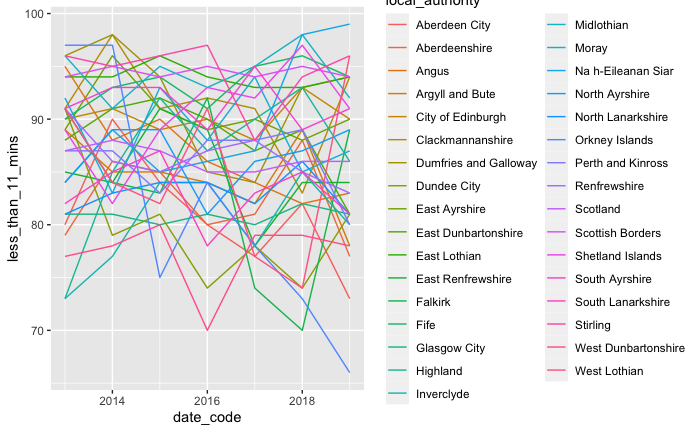

```r
all_la_percents %>%
  ggplot() +
  aes(x = date_code, y = less_than_11_mins, colour = local_authority) +
  geom_line()
```

```r
#Might have another go at a pivot to see if we can get multiple things on the board.

gb_long_pivot_back <-
gb_pivot_plus_less_11 %>%
  pivot_longer(c(age, gender, urban_rural_classification, simd_quintiles, type_of_tenure, household_type, ethnicity), names_to = "type", values_to = "class") %>%
  filter(class != "All")


gb_long_pivot_back
```

| feature_code | date_code | local_authority | within_a_6_10_minute_walk | an_11_minute_walk_or_more | a_5_minute_walk_or_less | dont_know | less_than_11_mins | type | class |
| --- | --- | --- | --- | --- | --- | --- | --- | --- | --- |
| S12000030 | 2013 | Stirling | 20 | 3 | 77 | NA | 97 | household_type | With Children |
| S12000050 | 2019 | North Lanarkshire | 13 | 21 | 65 | NA | 78 | household_type | With Children |
| S12000033 | 2017 | Aberdeen City | 14 | 15 | 69 | 2 | 83 | household_type | With Children |
| S12000021 | 2019 | North Ayrshire | 31 | 7 | 61 | NA | 92 | household_type | With Children |
| S12000042 | 2018 | Dundee City | 19 | 14 | 65 | 1 | 84 | household_type | With Children |
| S12000049 | 2014 | Glasgow City | 21 | 14 | 64 | 1 | 85 | household_type | With Children |
| S12000041 | 2016 | Angus | 28 | 13 | 59 | NA | 87 | household_type | With Children |
| S12000027 | 2017 | Shetland Islands | 15 | 7 | 78 | NA | 93 | household_type | With Children |
| S12000049 | 2015 | Glasgow City | 19 | 17 | 63 | 1 | 82 | household_type | With Children |
| S12000035 | 2014 | Argyll and Bute | 12 | 8 | 78 | 2 | 90 | household_type | With Children |

[output cut: 990 more lines]

Think I need another quick check on whether this has worked. Will go back to the original:

```r
gb_pivot_plus_less_11 %>%
  filter(local_authority == "Scotland",
         household_type == "With Children") %>%
  select(-c(type_of_tenure, ethnicity, age, gender, urban_rural_classification, simd_quintiles))
```

| feature_code | date_code | household_type | local_authority | within_a_6_10_minute_walk | an_11_minute_walk_or_more | a_5_minute_walk_or_less | dont_know | less_than_11_mins |
| --- | --- | --- | --- | --- | --- | --- | --- | --- |
| S92000003 | 2014 | With Children | Scotland | 17 | 10 | 72 | 1 | 89 |
| S92000003 | 2016 | With Children | Scotland | 20 | 11 | 68 | 0 | 88 |
| S92000003 | 2015 | With Children | Scotland | 17 | 10 | 72 | 0 | 89 |
| S92000003 | 2013 | With Children | Scotland | 18 | 12 | 70 | 1 | 88 |
| S92000003 | 2017 | With Children | Scotland | 18 | 11 | 70 | 0 | 88 |
| S92000003 | 2018 | With Children | Scotland | 20 | 9 | 71 | 0 | 91 |
| S92000003 | 2019 | With Children | Scotland | 19 | 13 | 68 | 1 | 87 |

```r
gb_long_pivot_back %>%
  filter(local_authority == "Scotland",
         class == "With Children")
```

| feature_code | date_code | local_authority | within_a_6_10_minute_walk | an_11_minute_walk_or_more | a_5_minute_walk_or_less | dont_know | less_than_11_mins | type | class |
| --- | --- | --- | --- | --- | --- | --- | --- | --- | --- |
| S92000003 | 2014 | Scotland | 17 | 10 | 72 | 1 | 89 | household_type | With Children |
| S92000003 | 2016 | Scotland | 20 | 11 | 68 | 0 | 88 | household_type | With Children |
| S92000003 | 2015 | Scotland | 17 | 10 | 72 | 0 | 89 | household_type | With Children |
| S92000003 | 2013 | Scotland | 18 | 12 | 70 | 1 | 88 | household_type | With Children |
| S92000003 | 2017 | Scotland | 18 | 11 | 70 | 0 | 88 | household_type | With Children |
| S92000003 | 2018 | Scotland | 20 | 9 | 71 | 0 | 91 | household_type | With Children |
| S92000003 | 2019 | Scotland | 19 | 13 | 68 | 1 | 87 | household_type | With Children |

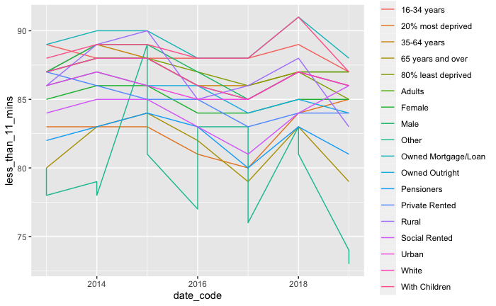

```r
gb_long_pivot_back %>%
  filter(local_authority == "Scotland") %>%
  ggplot() +
  aes(x = date_code, y = less_than_11_mins, colour = class) +
  geom_line()
```

Think about what else we could do with means over the date covered.

```r
all_la_percents_filtered <-
all_la_percents %>%
  select(c(date_code, feature_code, local_authority, less_than_11_mins, an_11_minute_walk_or_more, a_5_minute_walk_or_less, within_a_6_10_minute_walk, dont_know)) %>%
  rename(year = date_code)
```

```r
gb_long_back_ordered <-
gb_long_pivot_back %>%
  select(c(date_code, feature_code, local_authority, type, class, less_than_11_mins, an_11_minute_walk_or_more, a_5_minute_walk_or_less, within_a_6_10_minute_walk, dont_know)) %>%
  rename(year = date_code) %>%
  mutate(class = if_else((type == "ethnicity") &
                           (class == "Other"),
                         "Non_White_Ethnicity", class)) %>%
  mutate(class = if_else((type == "type_of_tenure") &
                           (class == "Other"),
                         "Other Tenure", class)) %>%
  mutate(class = recode(class, Adults = "Adults (non pension, no children)")) %>%
  arrange(local_authority, type, class, year)

gb_long_back_ordered
```

| year | feature_code | local_authority | type | class | less_than_11_mins | an_11_minute_walk_or_more | a_5_minute_walk_or_less | within_a_6_10_minute_walk | dont_know |
| --- | --- | --- | --- | --- | --- | --- | --- | --- | --- |
| 2013 | S12000033 | Aberdeen City | age | 16-34 years | 80 | 20 | 68 | 12 | NA |
| 2014 | S12000033 | Aberdeen City | age | 16-34 years | 93 | 5 | 79 | 14 | 1 |
| 2015 | S12000033 | Aberdeen City | age | 16-34 years | 83 | 15 | 53 | 30 | 1 |
| 2016 | S12000033 | Aberdeen City | age | 16-34 years | 80 | 18 | 60 | 20 | 2 |
| 2017 | S12000033 | Aberdeen City | age | 16-34 years | 80 | 16 | 64 | 16 | 4 |
| 2018 | S12000033 | Aberdeen City | age | 16-34 years | 86 | 11 | 63 | 23 | 3 |
| 2019 | S12000033 | Aberdeen City | age | 16-34 years | 76 | 23 | 60 | 16 | 1 |
| 2013 | S12000033 | Aberdeen City | age | 35-64 years | 82 | 17 | 63 | 19 | 1 |
| 2014 | S12000033 | Aberdeen City | age | 35-64 years | 92 | 7 | 77 | 15 | 0 |
| 2015 | S12000033 | Aberdeen City | age | 35-64 years | 85 | 15 | 64 | 21 | NA |

[output cut: 990 more lines]

```r
NA
NA
```

```r
write_csv(all_la_percents_filtered, "gb_local_authority_walk_dist_percent_shs.csv")
write_csv(gb_long_back_ordered, "gb_walk_dist_long_pivot_shs.csv")
```

Some extra checks for interesting combos with local authorities:

```r
gb_long_back_ordered %>%
  group_by(local_authority, class) %>%
  summarise(n = n())
```

| local_authority | class | n |
| --- | --- | --- |
| Aberdeen City | 16-34 years | 7 |
| Aberdeen City | 35-64 years | 7 |
| Aberdeen City | 65 years and over | 7 |
| Aberdeen City | 80% least deprived | 7 |
| Aberdeen City | Adults (non pension, no children) | 7 |
| Aberdeen City | Female | 7 |
| Aberdeen City | Male | 7 |
| Aberdeen City | Owned Mortgage/Loan | 7 |
| Aberdeen City | Owned Outright | 7 |
| Aberdeen City | Pensioners | 7 |

[output cut: 485 more lines]

```r
NA
NA
```

So it looks like we’ve got missing years for different classes, further complicating the analysis. Good to know though.